# 0: A demonstration of the growth model functions

FAO Climate Change Risks to Fed Mariculture

Author

Tormey Reimer

Published

25 August 2026

← Previous: Index

Next: Choosing species →

# Overview

This document demonstrates the major functions in `src/model_functions.R`, which implement a bioenergetic aquaculture growth model adapted from Baldan et al. (2018). The model simulates feed intake, metabolism, growth, and waste outputs for individual fish and whole farm populations.

The function hierarchy is:

1. **Helper functions** — `get_nitrogen()`, `get_carbon()`, `apportion_feed()`: convert macronutrient masses to elemental outputs and partition feed into waste fractions.
2. **Sub-functions** — `feeding_rate()`, `food_prov_rate()`: calculate temperature-dependent ingestion rates.
3. **Population function** — `generate_pop()`: back-calculates stocking numbers from a harvest target and mortality rate.
4. **Individual growth** — `fish_growth()`: integrates the full bioenergetic model for one individual over time.
5. **Farm-level functions** — `farm_growth_full()`, `consolidate_farm()`, `scale_farm_population()`: run many individuals in parallel, summarise across individuals, then scale by population size. The wrapper `farm_growth()` calls all three in sequence.
6. **Post-processing** — `decomposed_to_tidy()`, `convert_feed_to_levels()`: reshape results for plotting and analysis.

The sections below work through each layer in order, using illustrative Atlantic salmon parameters. Section 2 sets up all inputs needed to run any of the functions. Section 3 demonstrates the lower-level building blocks. Section 4 runs a single fish. Section 5 runs a full farm simulation and plots the key outputs.

# Setting up inputs

All functions share three input objects.

## Species parameters

`species_params` is a named numeric vector containing all bioenergetic, individual-variability, and feeding-rate parameters. The values below are illustrative defaults for Atlantic salmon (*Salmo salar*) — replace with species-appropriate values as needed.

**Define species_params — edit this chunk for your species**

```r
species_params <- c(
  # --- Bioenergetic parameters ---
  alpha     = 0.04,     # [-]        Feeding catabolism coefficient
  epsprot   = 23600,    # [J/gprot]  Energy content of protein
  epslip    = 36200,    # [J/glip]   Energy content of lipid
  epscarb   = 17200,    # [J/gcarb]  Energy content of carbohydrate
  epsO2     = 13400,    # [J/gO2]    Energy consumed per g of O2 respired
  pk        = 0.05,     # [1/day]    Temperature coefficient for fasting catabolism
  k0        = 0.003,    # [1/°C]     Fasting catabolism at 0 °C
  m         = 0.75,     # [-]        Weight exponent for anabolism
  n         = 1,        # [-]        Weight exponent for catabolism
  betac     = 0.3234,   # [-]        Shape coefficient for the H(Tw) feeding function
  Tma       = 26,       # [°C]       Maximum (lethal) feeding temperature
  Toa       = 16,       # [°C]       Optimal feeding temperature
  Taa       = 2,        # [°C]       Minimum (lower) feeding temperature
  omega     = 0.6542,   # [gO2/g]    Oxygen consumption–weight loss ratio
  a         = 2663,     # [J/g]      Energy density coefficient of somatic tissue
  k         = 0.1715,   # [-]        Weight exponent for energy content of tissue
  eff       = 0.97,     # [-]        Food ingestion efficiency (encounter → ingestion)
  # --- Population / individual-variability parameters ---
  meanW     =  125,     # [g]        Mean initial individual weight at stocking
  deltaW    =  10,      # [g]        SD of initial individual weight
  meanImax  =  0.035,   # [g/g/d]    Mean maximum mass-specific ingestion coefficient
  deltaImax  = 0.0035,  # [g/g/d]    SD of maximum ingestion coefficient
  overFmean  = 0.025,   # [g/g/d]    Mean of overfeeding coefficient
  overFdelta = 0.0045   # [g/g/d]    SD of maximum ingestion coefficient
)
```

## Feed parameters

`feed_params` is a named list with one entry per macronutrient. Each entry holds three vectors:

- **proportion**: The proportion of each ingredient in the feed (0-1). Note that this will be identical for all macronutrients and MUST SUM TO 1.
- **macro**: The proportion of each ingredient that is composed of that macronutrient (0-1).
- **digest**: The digestibility of that macronutrient, in that ingredient (0-1).

For whole-feed model runs where ingredients are not seperated, `proportion` == 1 for all list elements.

**Define feed_params — edit proportions and digestibilities for your feed**

```r
# Example where seperate ingredients within feed are considered
feed_params_ingredient <- list(
  Proteins = list(
    proportion = c(0.3, 0.3, 0.4),
    macro      = c(0.25, 0.5, 0.02),
    digest     = c(0.85, 0.9, 0.75)
  ),
  Lipids = list(
    proportion = c(0.3, 0.3, 0.4),
    macro      = c(0.1, 0.15, 0.9),
    digest     = c(0.2, 0.95, 0.85)
  ),
  Carbohydrates = list(
    proportion = c(0.3, 0.3, 0.4),
    macro      = c(0.6, 0.2, 0.05),
    digest     = c(0.45, 0.5, 0.95)
  )
)

# Example where only whole-feed is considered
feed_params_whole <- list(
  Proteins = list(
    proportion = 1,
    macro      = 0.25,
    digest     = 0.85
  ),
  Lipids = list(
    proportion = 1,
    macro      = 0.2,
    digest     = 0.90
  ),
  Carbohydrates = list(
    proportion = 1,
    macro      = 0.55,
    digest     = 0.65
  )
)
```

## Time vector and water temperature

`times` controls the integration window and time-step. `water_temp` is a numeric vector of daily sea surface temperatures for the grow-out period. Here a simple sinusoidal annual cycle is used as a placeholder, as shown in Figure 1.

**Define simulation duration and water temperature trajectory**

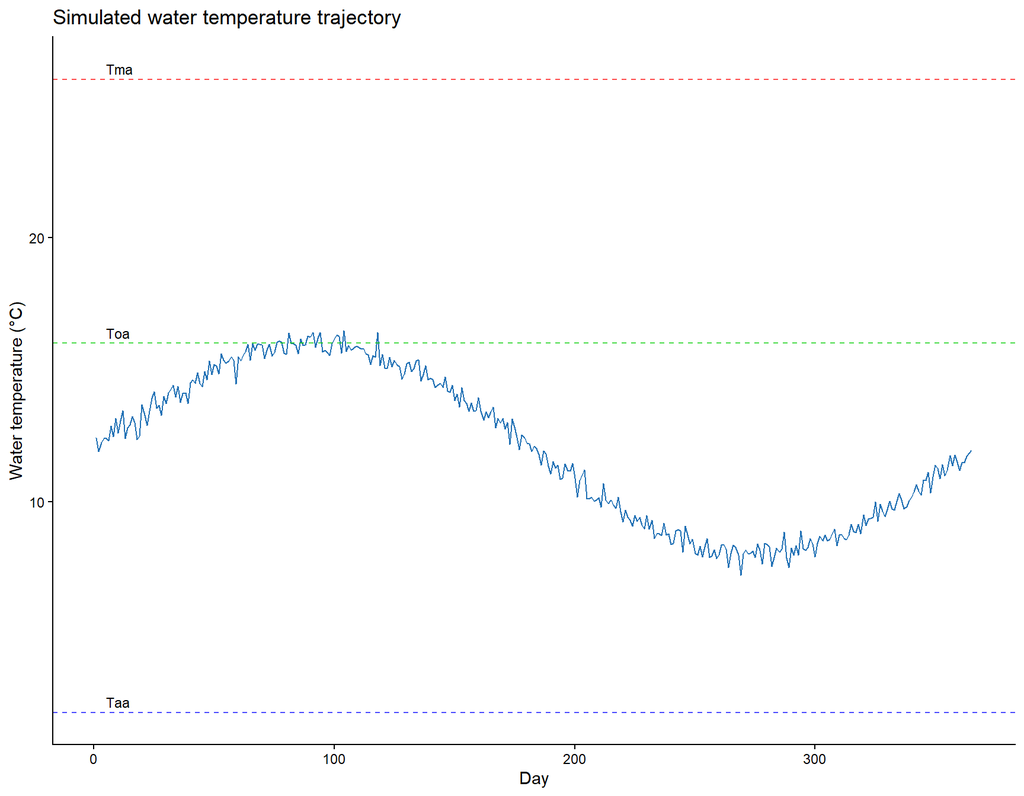

Figure 1: Simulated sinusoidal water temperature trajectory over the grow-out period. Dashed lines indicate the minimum (Taa), optimal (Toa), and maximum (Tma) feeding temperatures.

```r
grow_out_days <- 365L   # Duration of the grow-out cycle (days)

times <- c(
  t_start = 1L,              # First time-step index
  t_end   = grow_out_days,   # Last time-step index
  dt      = 1L               # Time-step size (days)
)

# Sinusoidal temperature trajectory: mean 12 °C, amplitude ±4 °C
# Replace with observed or projected SST data for real analyses
set.seed(42)
water_temp <- 12 + 4 * sin(seq(0, 2 * pi, length.out = grow_out_days)) +
  rnorm(grow_out_days, 0, 0.3)

# Quick check
data.frame(day = 1:grow_out_days, temp_C = water_temp) %>%
  ggplot(aes(day, temp_C)) +
  geom_line(colour = "#2171b5") +
  geom_hline(yintercept = c(species_params["Taa"], species_params["Toa"], species_params["Tma"]),
             linetype = "dashed", colour = c("blue", "green3", "red"), alpha = 0.7) +
  annotate("text", x = 5, y = species_params["Taa"] + 0.4, label = "Taa", hjust = 0, size = 3) +
  annotate("text", x = 5, y = species_params["Toa"] + 0.4, label = "Toa", hjust = 0, size = 3) +
  annotate("text", x = 5, y = species_params["Tma"] + 0.4, label = "Tma", hjust = 0, size = 3) +
  labs(x = "Day", y = "Water temperature (°C)",
       title = "Simulated water temperature trajectory") +
  theme_classic()
```

## Population trajectory

`generate_pop()` back-calculates the stocking density from a target harvest number and a constant daily mortality rate, returning a forward-order population vector. Figure 2 shows the resulting population decline over time.

**Generate population trajectory via generate_pop()**

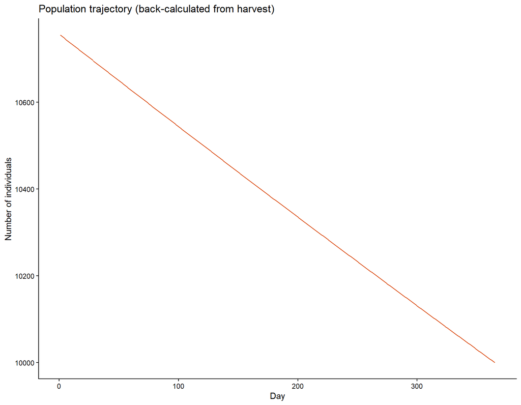

Figure 2: Population trajectory back-calculated from the harvest target, showing daily mortality-driven decline from stocking to harvest.

```r
harvest_n   <- 10000L   # Target number of fish alive at harvest
daily_mort  <- 0.0002   # Daily mortality rate (negative = gains)

N_pop <- generate_pop(
  harvest_n = harvest_n,
  mort      = daily_mort,
  times     = times
)

data.frame(day = 1:grow_out_days, n_fish = N_pop) %>%
  ggplot(aes(day, n_fish)) +
  geom_line(colour = "#d94701") +
  labs(x = "Day", y = "Number of individuals",
       title = "Population trajectory (back-calculated from harvest)") +
  theme_classic()
```

# Helper and sub-model functions

## Temperature-dependent feeding rate

**Plot the temperature-dependent feeding rate function**

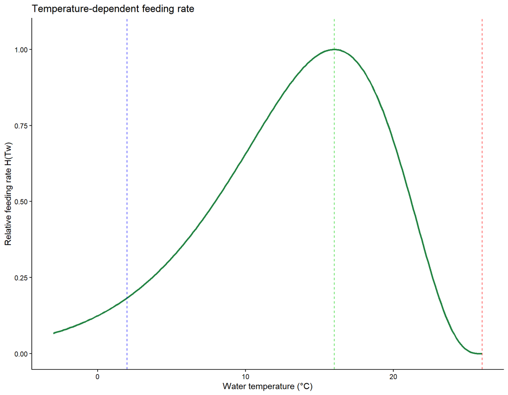

```r
temp_range <- seq(species_params["Taa"]-5, species_params["Tma"], length.out = 200)

data.frame(
  temp_C        = temp_range,
  feeding_rate  = feeding_rate(temp_range, species_params)
) %>%
  ggplot(aes(temp_C, feeding_rate)) +
  geom_line(colour = "#238443", linewidth = 1) +
  geom_vline(xintercept = c(species_params["Taa"], species_params["Toa"], species_params["Tma"]),
             linetype = "dashed", colour = c("blue", "green3", "red"), alpha = 0.7) +
  scale_y_continuous(limits = c(0, 1.05)) +
  labs(x = "Water temperature (°C)", y = "Relative feeding rate H(Tw)",
       title = "Temperature-dependent feeding rate") +
  theme_classic()
```

Figure 3 shows the shape of $H(T_w)$. The peak is at $T_{oa}$ = 16 °C, with the curve controlled by the shape parameter $\beta_c$ = 0.3234.

## Elemental conversion helpers

`get_nitrogen()` and `get_carbon()` convert macronutrient masses to nitrogen and carbon masses respectively, using fixed elemental conversion factors. These are used internally by `farm_growth_full()` and can also be called directly for post-processing.

**Demonstrate get_nitrogen() and get_carbon()**

```r
# Example: 100 g of feed containing 44 g protein, 20 g lipid, 15 g carbohydrate
P_feed <- 44; L_feed <- 20; C_feed <- 15

n_in_feed <- get_nitrogen(P = P_feed)
c_in_feed <- get_carbon(P = P_feed, L = L_feed, C = C_feed)

cat(sprintf(
  "100g Feed composition:  %g g protein, %g g lipid, %g g carbohydrate\n",
  P_feed, L_feed, C_feed
))
```

```
100g Feed composition:  44 g protein, 20 g lipid, 15 g carbohydrate
```

**Demonstrate get_nitrogen() and get_carbon()**

```r
cat(sprintf("  Nitrogen content: %.2f g  (= protein / 6.25)\n", n_in_feed))
```

```
  Nitrogen content: 7.04 g  (= protein / 6.25)
```

**Demonstrate get_nitrogen() and get_carbon()**

```r
cat(sprintf("  Carbon content:   %.2f g  (from P + L + C fractions)\n", c_in_feed))
```

```
  Carbon content:   43.49 g  (from P + L + C fractions)
```

## Feed apportioning

`apportion_feed()` partitions a single macronutrient component of the daily ration into uneaten, assimilated, and faecally excreted fractions. It can handle both whole-feed parameters and ingredient-seperated parameters.

**Demonstrate apportion_feed() for a single time-step**

```r
# Suppose at one time-step: 50 g feed provided, 42 g ingested
provided <- 50; ingested <- 42

protein_fractions <- apportion_feed(
  provided           = provided,
  ingested           = ingested,
  ingred_proportion  = feed_params_ingredient[["Proteins"]]$proportion,
  ingred_macro       = feed_params_ingredient[["Proteins"]]$macro,
  digestibility      = feed_params_ingredient[["Proteins"]]$digest
)

cat("Protein apportionment from ingredient-seperated feed (g):\n")
```

```
Protein apportionment from ingredient-seperated feed (g):
```

**Demonstrate apportion_feed() for a single time-step**

```r
print(round(protein_fractions, 3))
```

```
    uneaten assimilated    excreted
      1.864       8.599       1.187
```

**Demonstrate apportion_feed() for a single time-step**

```r
protein_fractions <- apportion_feed(
  provided           = provided,
  ingested           = ingested,
  ingred_proportion  = feed_params_whole[["Proteins"]]$proportion,
  ingred_macro       = feed_params_whole[["Proteins"]]$macro,
  digestibility      = feed_params_whole[["Proteins"]]$digest
)

cat("Protein apportionment from whole feed (g):\n")
```

```
Protein apportionment from whole feed (g):
```

**Demonstrate apportion_feed() for a single time-step**

```r
print(round(protein_fractions, 3))
```

```
    uneaten assimilated    excreted
      2.000       8.925       1.575
```

# Individual fish growth

**Run fish_growth() for a single individual**

```r
one_fish <- fish_growth(
  species_params = species_params,
  water_temp     = water_temp,
  feed_params    = feed_params_whole,
  times          = times,
  init_weight    = species_params["meanW"],    # Use mean stocking weight
  ingmax         = species_params["meanImax"]  # Use mean ingestion coefficient
)

cat(sprintf("Result dimensions: %d days × %d variables\n", nrow(one_fish), ncol(one_fish)))
```

```
Result dimensions: 365 days × 32 variables
```

**Run fish_growth() for a single individual**

```r
cat("Available variables:\n")
```

```
Available variables:
```

**Run fish_growth() for a single individual**

```r
cat(paste(colnames(one_fish), collapse = ", "), "\n")
```

[output not shown]

**Run fish_growth() for a single individual**

```r
cat(sprintf("\nFinal weight: %.1f g  (started at %.1f g)\n",
            tail(one_fish[, "weight"], 1), one_fish[1, "weight"]))
```

```
Final weight: 2.3 g  (started at 125.0 g)
```

Figure 4 shows the weight trajectory of this individual throughout the grow-out cycle. Figure 5 shows the daily waste outputs.

**Plot individual weight trajectory**

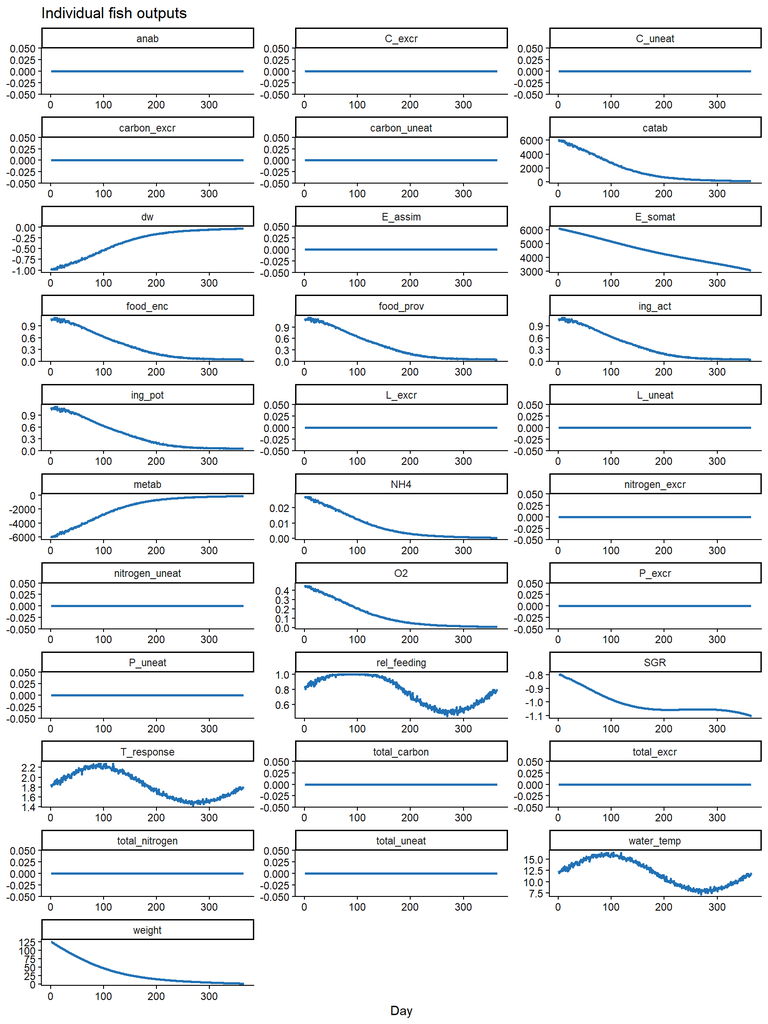

```r
as.data.frame(one_fish) %>%
  pivot_longer(
    cols = !contains("days"),
    names_to = "output_var",
    values_to = "value"
  ) %>%
  ggplot(aes(days, value)) +
  geom_line(colour = "#2171b5", linewidth = 1) +
  facet_wrap(~output_var, scales = "free", ncol = 3) +
  labs(x = "Day", title = "Individual fish outputs") +
  theme_classic() +
  theme(axis.title.y = element_blank())
```

You can subset the variables you want returned in case you don’t want to deal with the whole gamut of output variables.

**Run fish_growth() for a single individual with a limited selection of variables**

```r
one_fish <- fish_growth(
  species_params = species_params,
  water_temp     = water_temp,
  feed_params    = feed_params_whole,
  times          = times,
  init_weight    = species_params["meanW"],    # Use mean stocking weight
  ingmax         = species_params["meanImax"],  # Use mean ingestion coefficient
  output_vars = c("P_excr", "L_excr", "C_excr", "P_uneat", "L_uneat", "C_uneat")
)

cat(sprintf("Result dimensions: %d days × %d variables\n", nrow(one_fish), ncol(one_fish)))
```

```
Result dimensions: 365 days × 7 variables
```

**Run fish_growth() for a single individual with a limited selection of variables**

```r
cat("Available variables:\n")
```

```
Available variables:
```

**Run fish_growth() for a single individual with a limited selection of variables**

```r
cat(paste(colnames(one_fish), collapse = ", "), "\n")
```

```
days, P_excr, L_excr, C_excr, P_uneat, L_uneat, C_uneat
```

**Plot daily waste outputs for the individual**

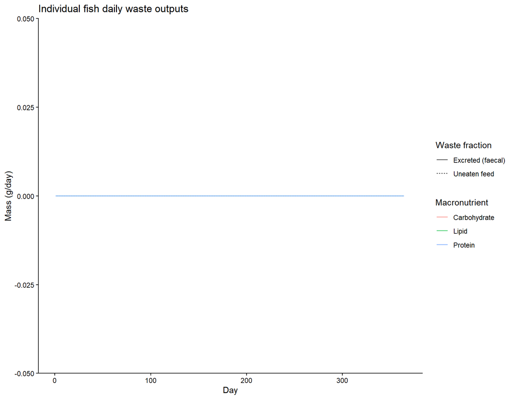

Figure 5: Daily protein, lipid, and carbohydrate excretion and uneaten-feed waste for one individual fish.

```r
as.data.frame(one_fish) %>%
  pivot_longer(-days, names_to = "variable", values_to = "value") %>%
  mutate(
    fraction = if_else(str_detect(variable, "excr"), "Excreted (faecal)", "Uneaten feed"),
    nutrient = case_when(
      str_detect(variable, "^P") ~ "Protein",
      str_detect(variable, "^L") ~ "Lipid",
      str_detect(variable, "^C") ~ "Carbohydrate"
    )
  ) %>%
  ggplot(aes(days, value, colour = nutrient, linetype = fraction)) +
  geom_line(alpha = 0.8) +
  labs(x = "Day", y = "Mass (g/day)", colour = "Macronutrient",
       linetype = "Waste fraction",
       title = "Individual fish daily waste outputs") +
  theme_classic()
```

# Farm-level simulation

## Running the full farm

`farm_growth()` is the main wrapper. It runs `MC_pop` individuals in parallel (Monte Carlo sampling of initial weights and ingestion rates from the distributions defined in `species_params`), consolidates the individual trajectories to per-time-step means and standard deviations, then scales population-total variables by `N_pop`.

```r
# Step 1: Get the full (individualised) results for all Monte-Carlo-sampled individual fish in the farm.
farm_results_full <- farm_growth_full(
  species_params    = species_params,
  feed_params       = feed_params_whole,
  water_temp        = water_temp,
  times             = times,
  use_MC_population = TRUE,        # Sample individual variability
  MC_pop            = 200          # Number of Monte Carlo individuals
)

# Consolidate all MC-sampled individuals in the farm into a representative mean and SD for each stat
consolidated_results  <- consolidate_farm(farm_results_full)

# Scale certain parameters by farm population to obtain a farm-level version of some of those stats
scaled_farm_results <- scale_farm_population(
  consolidated_results,
  N_pop = N_pop
)
```

**Run the full farm simulation with farm_growth()**

```r
plan(multisession)  # Enable parallel processing via furrr

farm_results <- farm_growth(
  species_params    = species_params,
  feed_params       = feed_params_whole,
  water_temp        = water_temp,
  times             = times,
  N_pop             = N_pop,       # Number of actual individuals in the farm
  use_MC_population = TRUE,        # Sample individual variability
  MC_pop            = 200          # Number of Monte Carlo individuals
)

plan(sequential)  # Return to sequential after parallel run

cat("Output variables (each is a days × mean × SD matrix):\n")
```

```
Output variables (each is a days × mean × SD matrix):
```

**Run the full farm simulation with farm_growth()**

```r
cat(paste(names(farm_results$stats), collapse = "\n"), "\n")
```

```
weight
dw
water_temp
T_response
P_excr
L_excr
C_excr
P_uneat
L_uneat
C_uneat
food_prov
food_enc
rel_feeding
ing_pot
ing_act
E_assim
E_somat
anab
catab
O2
NH4
total_excr
total_uneat
metab
nitrogen_excr
nitrogen_uneat
carbon_excr
carbon_uneat
total_carbon
total_nitrogen
SGR
weight_scaled
dw_scaled
P_excr_scaled
L_excr_scaled
C_excr_scaled
P_uneat_scaled
L_uneat_scaled
C_uneat_scaled
ing_act_scaled
total_excr_scaled
total_uneat_scaled
O2_scaled
NH4_scaled
food_prov_scaled
nitrogen_excr_scaled
nitrogen_uneat_scaled
carbon_excr_scaled
carbon_uneat_scaled
total_carbon_scaled
total_nitrogen_scaled
```

## Inspecting the structure

There are two elements in `farm_results`. The first contains a vector of the days, which applies to the entire farm. The second element is a list of results. Each of these elements is a two-column matrix. The first column is the mean, and the second is the standard deviation.

**Inspect the structure of farm_results**

```r
# Days element
head(farm_results$days)
```

```
[1] 1 2 3 4 5 6
```

**Inspect the structure of farm_results**

```r
# Example: weight_scaled — total farm biomass over time
head(farm_results$stats[["weight_scaled"]])
```

```
        [,1]     [,2]
[1,] 1351248 106773.0
[2,] 1340150 106042.1
[3,] 1329400 105333.1
[4,] 1318540 104615.8
[5,] 1307675 103897.3
[6,] 1296885 103182.8
```

## Plotting farm biomass and waste

Figure 6 shows the total farm biomass trajectory with uncertainty bands. Figure 7 shows the total daily waste outputs over the grow-out period.

**Plot total farm biomass over time**

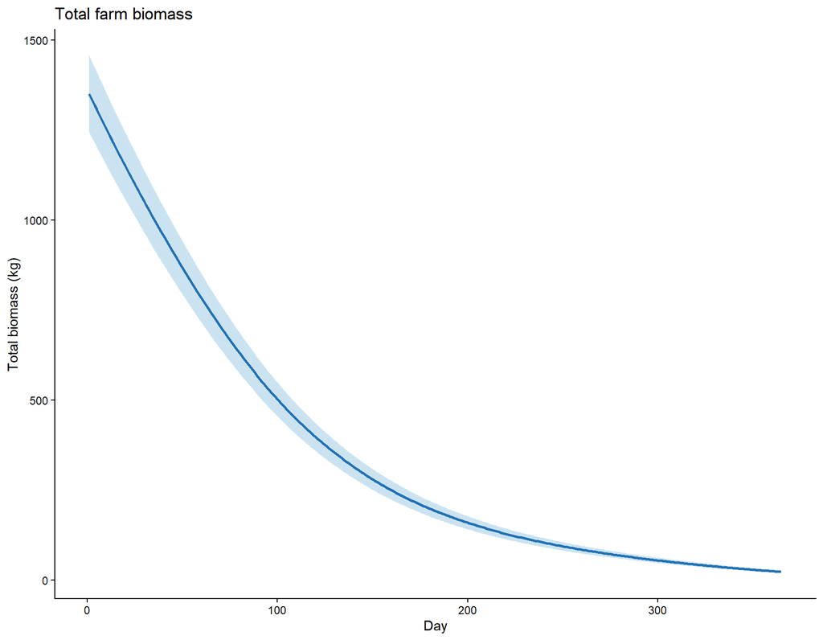

Figure 6: Total farm biomass (kg) over the grow-out period. Shaded ribbon shows ±1 SD across Monte Carlo individuals, scaled by the population trajectory.

```r
cbind(
  as.data.frame(farm_results$days),
  as.data.frame(farm_results$stats[["weight_scaled"]])
  ) %>%
  setNames(c("day", "mean_g", "sd_g")) %>%
  mutate(
    mean_kg = mean_g / 1000,
    lo_kg   = (mean_g - sd_g) / 1000,
    hi_kg   = (mean_g + sd_g) / 1000
  ) %>%
  ggplot(aes(day)) +
  geom_ribbon(aes(ymin = lo_kg, ymax = hi_kg), fill = "#6baed6", alpha = 0.35) +
  geom_line(aes(y = mean_kg), colour = "#2171b5", linewidth = 1) +
  labs(x = "Day", y = "Total biomass (kg)",
       title = "Total farm biomass") +
  theme_classic()
```

**Plot total daily waste from the farm**

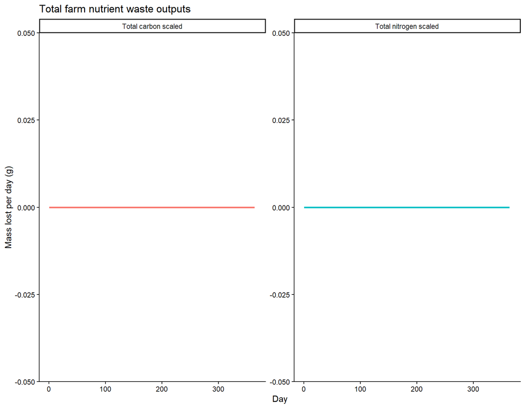

Figure 7: Total daily waste outputs from the farm: nitrogen and carbon lost via excretion and uneaten feed.

```r
waste_vars <- c("total_nitrogen_scaled", "total_carbon_scaled")

map_dfr(waste_vars, function(nm) {
  cbind(
    as.data.frame(farm_results$days),
    as.data.frame(farm_results$stats[[nm]])
   ) %>%
    setNames(c("day", "mean", "sd")) %>%
    mutate(variable = nm)
}) %>%
  mutate(variable = str_remove(variable, "_stat") %>%
           str_replace("total_", "Total ") %>%
           str_replace("_", " ")) %>%
  ggplot(aes(day)) +
  geom_ribbon(aes(ymin = mean - sd, ymax = mean + sd, fill = variable), alpha = 0.3) +
  geom_line(aes(y = mean, colour = variable), linewidth = 0.9) +
  facet_wrap(~variable, scales = "free") +
  labs(x = "Day", y = "Mass lost per day (g)",
       colour = NULL, fill = NULL,
       title = "Total farm nutrient waste outputs") +
  theme_classic() +
  theme(legend.position = "none")
```

## Accessing full individual trajectories

To examine individual-level variation — for example when plotting per-fish trajectories or comparing simulated individuals — use `farm_growth_full()` directly. The result is a named list of `MC_pop × n_days` matrices. `decomposed_to_tidy()` reshapes a selection of these into a tidy long-format data frame.

**Run farm_growth_full() and convert to tidy format with decomposed_to_tidy()**

```r
plan(multisession)

full_results <- farm_growth_full(
  species_params    = species_params,
  feed_params       = feed_params_whole,
  water_temp        = water_temp,
  times             = times,
  use_MC_population = TRUE,
  MC_pop            = 50,          # Fewer runs for quick illustration
  output_vars       = c("weight", "ing_act", "O2", "NH4")
)

plan(sequential)

# Convert selected variables to a tidy data frame
tidy_results <- decomposed_to_tidy(
  full_results = full_results,
  output_vars  = NULL             # Since I already
)

head(tidy_results)
```

```
  fish prod_t    value measure
1    1      1 136.3991  weight
2    2      1 137.3604  weight
3    3      1 127.9540  weight
4    4      1 126.7176  weight
5    5      1 115.4461  weight
6    6      1 112.8959  weight
```

Figure 8 shows weight trajectories across all 50 simulated individuals, illustrating the Monte Carlo population variability.

**Plot weight trajectories across Monte Carlo individuals**

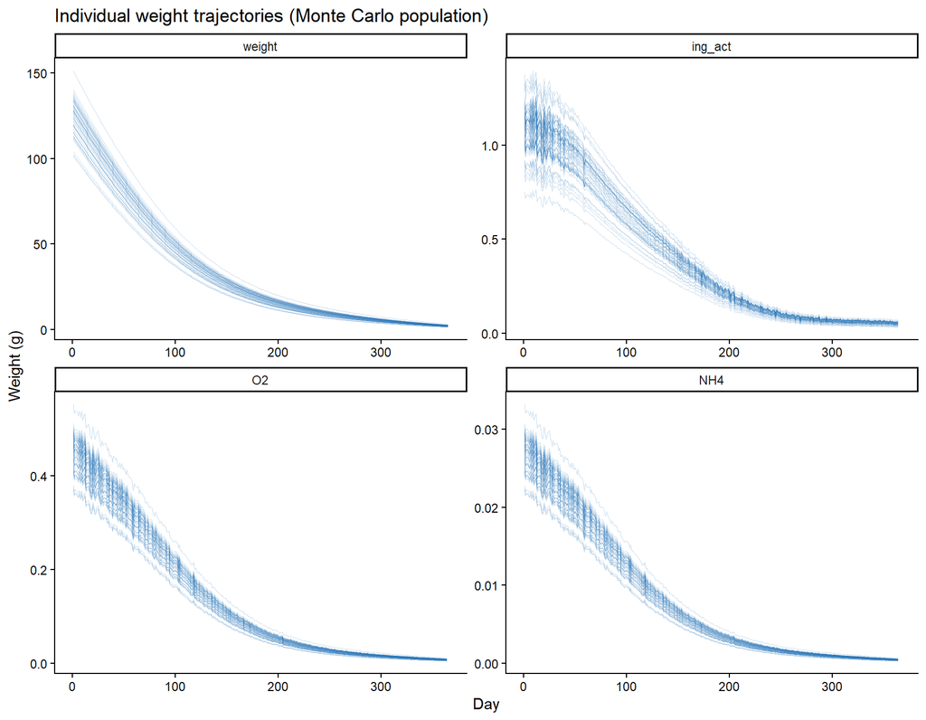

Figure 8: Several measure trajectories for 50 simulated individuals. Variability arises from Monte Carlo sampling of initial weight and maximum ingestion rate from the distributions defined in species_params.

```r
tidy_results %>%
  ggplot(aes(prod_t, value, group = fish)) +
  geom_line(alpha = 0.25, colour = "#2171b5", linewidth = 0.3) +
  facet_wrap(~measure, scales = "free") +
  labs(x = "Day", y = "Weight (g)",
       title = "Individual weight trajectories (Monte Carlo population)") +
  theme_classic()
```

## Deterministic (no population variability) run

Setting `use_MC_population = FALSE` removes individual variability and forces `MC_pop` to 1.

**Run farm_growth() without Monte Carlo population variability**

```r
farm_det <- farm_growth(
  species_params    = species_params,
  feed_params       = feed_params_whole,
  water_temp        = water_temp,
  times             = times,
  N_pop             = N_pop,
  use_MC_population = FALSE,
  MC_pop            = 100,    # this number is IGNORED
)

cat(
  sprintf(
    "Deterministic final biomass: %.2f kg\n",
    tail(farm_det$stats[["weight"]][, 1], 1) / 1000
  ),
  sprintf(
    "SD of final biomass: %.2f\n",
    tail(farm_det$stats[["weight"]][, 2], 1) / 1000
  )
)
```

```
Deterministic final biomass: 0.00 kg
 SD of final biomass: NA
```

← Previous: Index

Next: Choosing species →